# Gramática dos gráficos com ggplot2

Aula 05 · Introdução à Linguagem R

Diogo B. Provete

PPG em Ecologia e Conservação · UFMS

## De onde vem a ideia

Wilkinson, L. (2005). **The Grammar of Graphics.** 2ª ed. Springer. [doi:10.1007/0-387-28695-0](https://doi.org/10.1007/0-387-28695-0)

Wickham, H. (2010). **A Layered Grammar of Graphics.** *Journal of Computational and Graphical Statistics* 19(1): 3–28. [doi:10.1198/jcgs.2009.07098](https://doi.org/10.1198/jcgs.2009.07098)

A tese dos dois: um gráfico não é um **tipo** que você escolhe de um menu. É uma **frase** que você monta com peças que se combinam.

É por isso que o `ggplot2` não tem uma função `grafico_de_barras()`.

## Onde aprender mais

- [R for Data Science](https://r4ds.hadley.nz) — capítulos de visualização
- [ggplot2: Elegant Graphics for Data Analysis](https://ggplot2-book.org) — o livro do pacote
- [Análises Ecológicas no R](https://analises-ecologicas.com/cap6.html) — capítulo 6, em português

Boa parte desta aula é adaptada do curso de [Gustavo Paterno](https://paternogbc.github.io/disciplina-graficos-r/).

# As três camadas

## O que é um gráfico

[figure not shown]

- **Data** — a tabela
- **Aesthetics** — o *mapeamento*: qual coluna vira qual propriedade visual
- **Geometries** — a *representação*: que forma desenha cada observação

Figura do curso de [Gustavo Paterno](https://paternogbc.github.io/disciplina-graficos-r/)

## Os dados do exemplo

Vulnerabilidades registradas por aplicativo:

| APPLICATION | TOTAL | HIGH | MEDIUM | LOW | SCORE |
| --- | --- | --- | --- | --- | --- |
| Apple Safari | 81 | 2 | 71 | 8 | 413 |
| Mozilla Firefox | 44 | 3 | 30 | 11 | 236 |
| Google Chrome | 61 | 1 | 30 | 30 | 205 |
| Microsoft Internet Explorer | 34 | 1 | 30 | 3 | 178 |
| Adobe Flash Player | 34 | 0 | 34 | 0 | 170 |
| Java Runtime Environment | 28 | 5 | 5 | 18 | 168 |

Tabela do curso de [Gustavo Paterno](https://paternogbc.github.io/disciplina-graficos-r/) · mostrando 6 de 15 linhas

## Duas variáveis contínuas

1. **Dados** — a tabela acima
2. **Mapeamento** — `x = HIGH`, `y = TOTAL`
3. **Geometria** — `point`
4. **Gráfico** — um ponto por aplicativo

```r
ggplot(dados, aes(x = HIGH, y = TOTAL)) +
  geom_point()
```

## Uma variável contínua

1. **Dados** — a mesma tabela
2. **Mapeamento** — `x = HIGH`. **Só isso.**
3. **Geometria** — `histogram`
4. **Gráfico** — o eixo Y aparece sozinho: é a **contagem**

```r
ggplot(dados, aes(x = HIGH)) +
  geom_histogram()
```

Repare: você não pediu o eixo Y. A geometria calculou.

# A tradução para o R

## Cada camada é um pedaço do comando

| Camada | No R |
| --- | --- |
| **Dados** | objeto da classe `data.frame` |
| **Mapeamento** | colunas do `data.frame` — X, Y, grupos, cor, preenchimento |
| **Geometria** | uma função da família `geom_` |

```r
ggplot(data, aes(x, y)) + geom_point()
```

- `data` — define o objeto com a tabela
- `aes()` — define qual coluna é X e qual é Y
- `geom_` — define qual geometria plotar

## O sinal de `+`

```r
ggplot(data, aes(x, y)) +
  geom_point() +
  theme_classic() +
  labs(x = "Gravidade alta", y = "Total")
```

O `+` **adiciona camadas**. Uma camada por linha, sempre — facilita ler, facilita comentar uma linha para testar, e facilita achar o erro.

Erro clássico: pôr o `+` no começo da linha seguinte em vez do fim da anterior. O R não entende — ele precisa saber que a frase continua.

# Mapeamento

## Mapear é traduzir coluna em propriedade visual

Usando o `iris`, que já vem com o R:

```r
head(iris)
```

| Sepal.Length | Sepal.Width | Petal.Length | Petal.Width | Species |
| --- | --- | --- | --- | --- |
| 5.1 | 3.5 | 1.4 | 0.2 | setosa |
| 4.9 | 3.0 | 1.4 | 0.2 | setosa |
| 4.7 | 3.2 | 1.3 | 0.2 | setosa |

## O mesmo gráfico, mapeamentos diferentes

```r
ggplot(iris, aes(x = Sepal.Length, y = Petal.Length)) +
  geom_point()
```

```r
ggplot(iris, aes(x = Sepal.Length, y = Petal.Length,
                 color = Species)) +
  geom_point()
```

```r
ggplot(iris, aes(x = Sepal.Length, y = Petal.Length,
                 color = Species, shape = Species)) +
  geom_point(size = 3)
```

Os dados não mudaram. Só o que você pediu para o gráfico dizer sobre eles.

## Dentro ou fora do `aes()`?

```r
geom_point(aes(color = Species))   # cor VEM DOS DADOS
geom_point(color = "red")          # cor é uma DECISÃO SUA
```

- Dentro do `aes()` → o valor da cor depende da linha. Ganha legenda.
- Fora do `aes()` → todos os pontos ficam iguais. Sem legenda.

É o erro nº 1 de quem está começando. Legenda estranha? Confira se algo que deveria estar fora do `aes()` foi parar dentro.

## Discretas vs. contínuas

- O ggplot trata qualquer variável **categórica** como **discreta**
- Variáveis de texto costumam virar **fatores** no R
- Fatores são discretos: mapeados por **níveis**, não de forma contínua

```r
ggplot(iris, aes(x = Sepal.Length, y = Petal.Length,
                 color = Petal.Width)) + geom_point()
# escala contínua: um gradiente

ggplot(iris, aes(x = Sepal.Length, y = Petal.Length,
                 color = factor(Petal.Width))) + geom_point()
# escala discreta: uma cor por valor
```

`factor()` é o interruptor entre os dois mundos.

# Os cinco gráficos básicos

## Qual gráfico usar?

[figure not shown]

Adaptado do curso de [Gustavo Paterno](https://paternogbc.github.io/disciplina-graficos-r/)

## Histograma — `geom_histogram()`

Representa a **distribuição** de uma variável numérica.

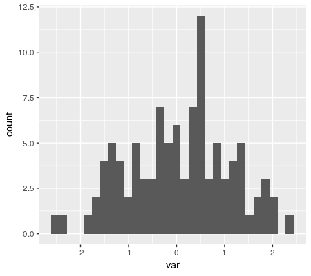

```r
ggplot(dados, aes(x = var)) +
  geom_histogram()
```

Uma variável numérica. O eixo Y é contagem, calculada pela geometria.

## Barras — `geom_bar()`

Representa variáveis **categóricas** com barras de comprimento proporcional ao valor.

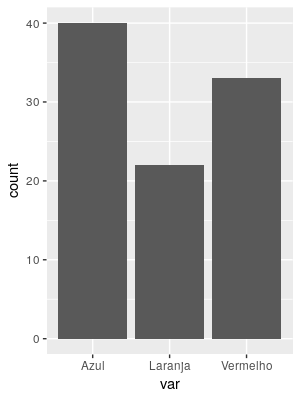

```r
ggplot(dados, aes(x = var)) +
  geom_bar()
```

Uma variável categórica. `geom_bar()` conta; `geom_col()` usa um valor que você já tem.

## Boxplot — `geom_boxplot()`

Quartis de uma variável numérica em função de uma variável categórica.

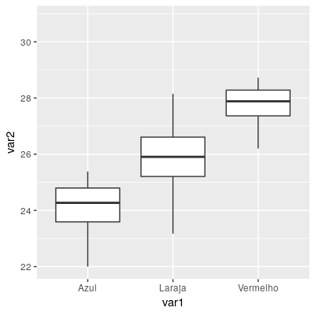

```r
ggplot(dados, aes(x = grupo, y = medida)) +
  geom_boxplot()
```

## Anatomia do boxplot

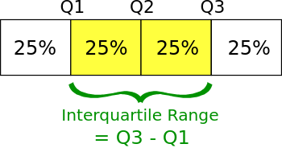

- A linha do meio é a **mediana**, não a média
- A caixa vai do 1º ao 3º quartil — **50% dos dados**
- As hastes vão até 1,5 × IQR; o que passa disso vira ponto

## Dispersão — `geom_point()`

A relação entre **duas variáveis numéricas**.

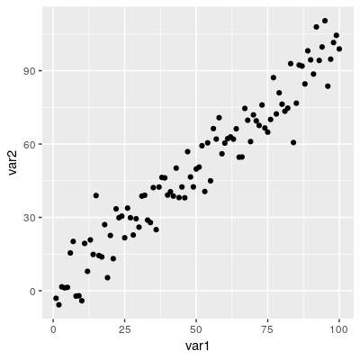

```r
ggplot(dados, aes(x = var1, y = var2)) +
  geom_point()
```

## Linha — `geom_line()`

Dados em série, conectados por segmentos de reta.

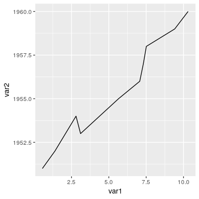

```r
ggplot(dados, aes(x = var1, y = var2)) +
  geom_line()
```

Linha só faz sentido com **um** valor de Y por X, e com um X que tenha ordem — tempo, distância, altitude.

# Combinando camadas

## Desafio: como juntar os dois?

Você tem um gráfico de dispersão e quer a linha de tendência por cima.

```r
ggplot(dados, aes(x = var1, y = var2)) +
  geom_point() +
  geom_smooth(method = "lm")
```

Repare que `aes()` foi declarado **uma vez**, no `ggplot()`. As duas geometrias herdam o mesmo mapeamento.

## A ordem das camadas importa

```r
ggplot(iris, aes(Sepal.Length, Petal.Length)) +
  geom_point() +
  geom_smooth()      # a linha fica POR CIMA dos pontos
```

```r
ggplot(iris, aes(Sepal.Length, Petal.Length)) +
  geom_smooth() +
  geom_point()       # os pontos ficam POR CIMA da linha
```

É como empilhar transparências: a última entra na frente.

# Ferramentas e exemplos

## `esquisse` — montar o gráfico clicando

Um *add-in* do RStudio: você arrasta as colunas, ele monta o gráfico — e **devolve o código do ggplot2**.

```r
install.packages("esquisse")
esquisse::esquisser()
```

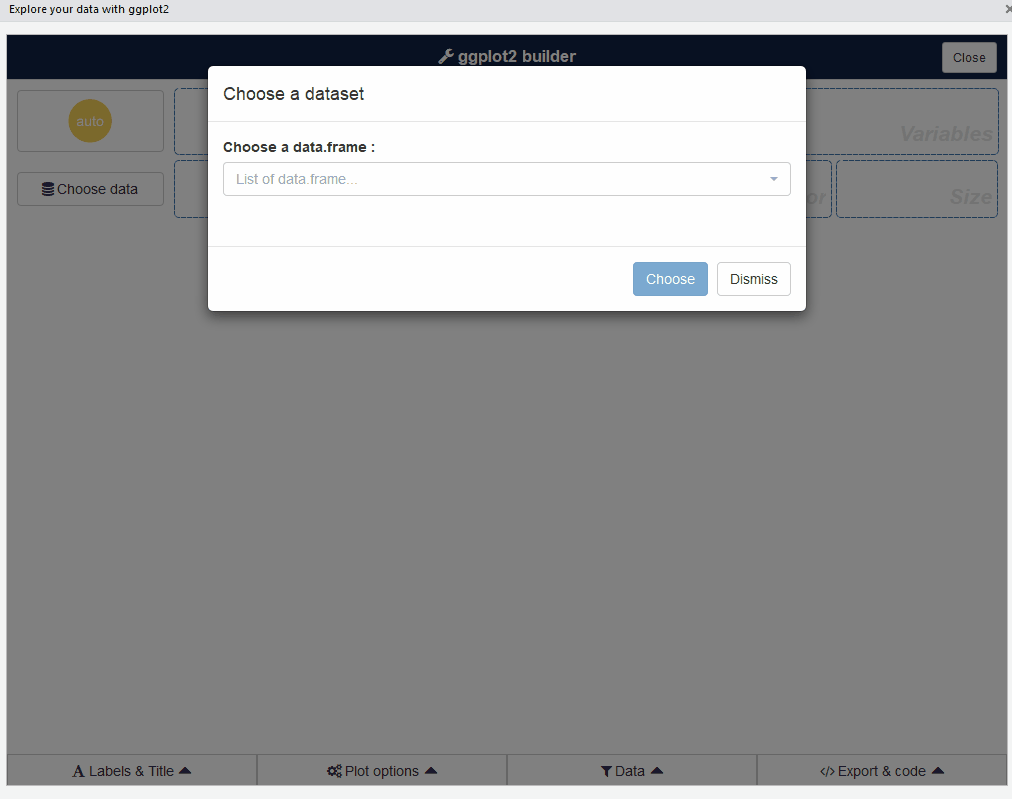

[Documentação do esquisse](https://dreamrs.github.io/esquisse/) · Bom para explorar e para aprender a sintaxe. Ruim como muleta permanente — o código que fica no script é o que garante reprodutibilidade.

## O que dá para fazer

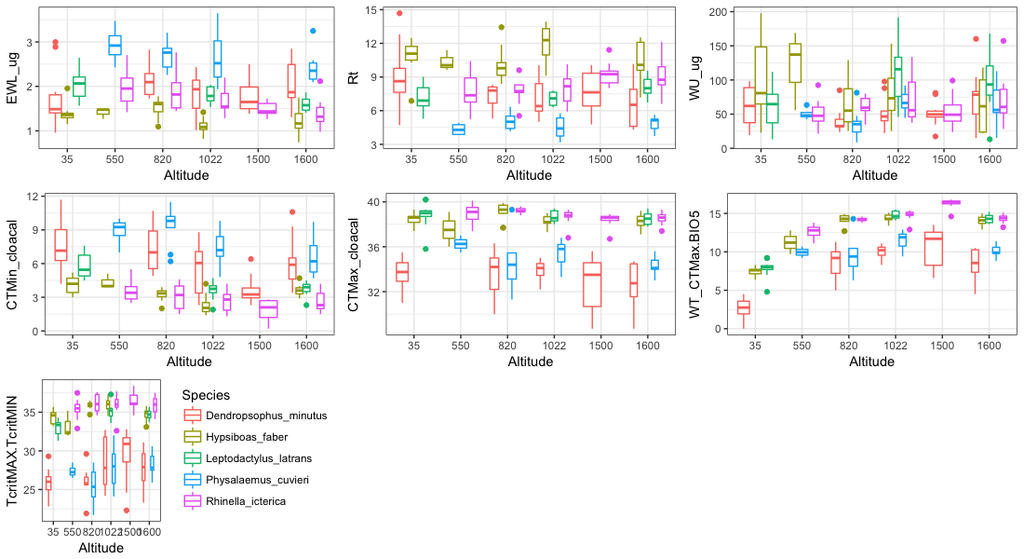

Bovo, R.P.; Simon, M.N.; **Provete, D.B.**; Lyra, M.; Navas, C.A.; Andrade, D.V. (2023). **Beyond Janzen’s Hypothesis: How Amphibians That Climb Tropical Mountains Respond to Climate Variation.** *Integrative Organismal Biology* 5(1): obad009. [doi:10.1093/iob/obad009](https://doi.org/10.1093/iob/obad009)

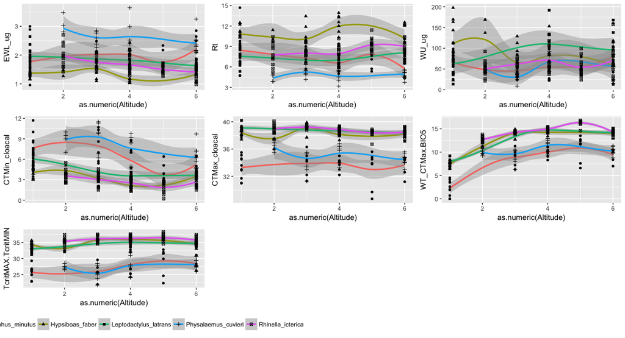

Mesmos dados, com `geom_smooth()` por espécie — Bovo et al. (2023). Sete variáveis fisiológicas, seis altitudes, cinco espécies, **um bloco de código**.

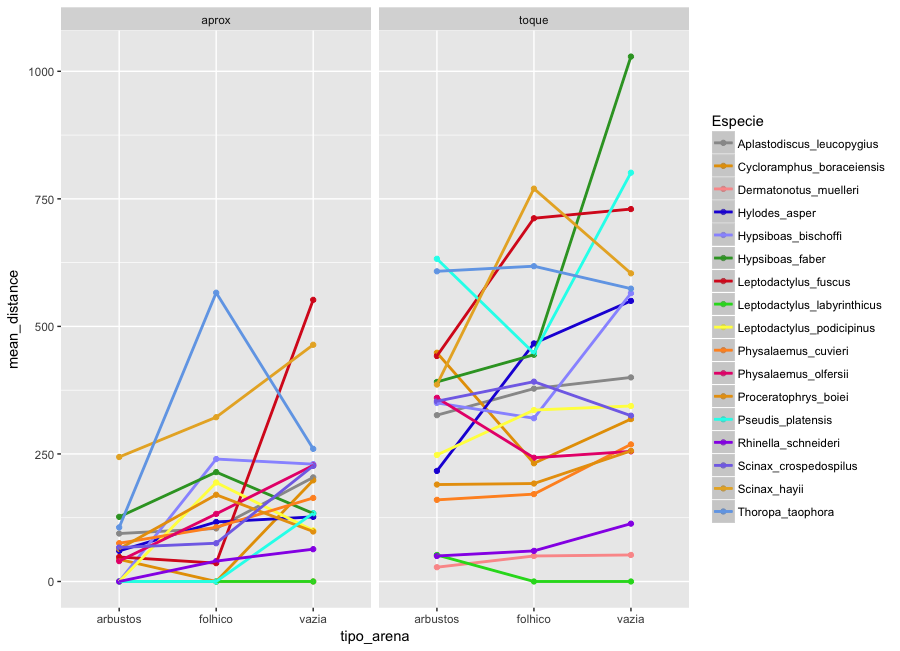

Distância de fuga por tipo de arena e tipo de estímulo, em 17 espécies de anuros. Citadini, J. *et al.* — manuscrito **em avaliação**.

## E uma feita nesta semana

[figure not shown]

Crescimento de girinos: comprimento rostro-cloacal por estágio de Gosner, por sexo, em três zonas. Dados de campo de Javier.

```r
library(ggplot2)
d <- read.table("javier_renacuajos.txt", header = TRUE)
d$zona <- factor(d$zona, labels = c("Zona 1", "Zona 2", "Zona 3"))

ggplot(d, aes(x = estadio, y = LHC, colour = sexo)) +
  geom_point(size = 1.9, alpha = .75) +
  geom_smooth(method = "lm", formula = y ~ x) +
  facet_wrap(~ zona) +
  labs(x = "Estágio de desenvolvimento (Gosner)",
       y = "Comprimento rostro-cloacal (mm)") +
  theme_minimal()
```

**Dez linhas.** Dados, mapeamento (`x`, `y`, `colour`), duas geometrias, uma estatística, facetas e rótulos — tudo o que vimos hoje, numa figura só.

## Um último: o que está errado aqui?

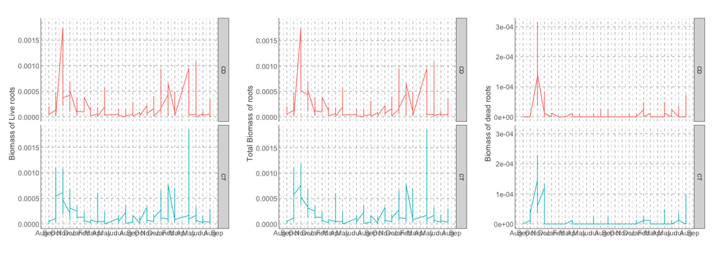

Os rótulos do eixo X estão ilegíveis, sobrepostos. Um gráfico bonito que ninguém consegue ler não é um gráfico bonito. **Como vocês consertariam?**

## Exercitando

Em [Análises Ecológicas no R](https://analises-ecologicas.com/cap6.html), capítulo 6:

- Leiam a seção [Gramática dos gráficos](https://analises-ecologicas.com/cap6.html#grámatica-dos-gráficos)
- Façam os [exercícios](https://analises-ecologicas.com/cap6.html#exerc%C3%ADcios-2)

Regra da aula: **nada de `esquisse` nos exercícios.** Escrevam o código.